# Income Classification Using Logistic Regression

## Introduction

This project aims to classify income levels based on various demographic and socio-economic features using Logistic Regression. The dataset contains information such as age, education, occupation, and more, with the target variable being whether an individual's income exceeds $50K per year.

## Objective

The primary objective of this project is to build a predictive model that accurately classifies individuals into different income brackets. We will use Logistic Regression due to its efficiency and interpretability for binary classification problems.

## Steps

1. Data Loading and Cleaning
2. Exploratory Data Analysis (EDA)
3. Feature Engineering
4. Model Building and Evaluation
5. Conclusion and Insights

## 1. Data Loading and Cleaning

In this section, we will load the dataset and perform initial data cleaning steps. This includes handling missing values, encoding categorical features, and scaling numerical features.

```python
# Load Libraries and Import Modules
import numpy as np
import pandas as pd
import matplotlib.pyplot as plt
import seaborn as sns
from scipy import stats
from scipy.stats import chi2_contingency
from sklearn.model_selection import GridSearchCV
from sklearn.linear_model import LogisticRegressionCV
from sklearn.model_selection import train_test_split
from sklearn.linear_model import LogisticRegression
from sklearn.metrics import confusion_matrix, classification_report, accuracy_score, precision_score, recall_score, f1_score, roc_curve, roc_auc_score
from sklearn.preprocessing import StandardScaler
```

```python
# !pip install ucimlrepo
```

```python
from ucimlrepo import fetch_ucirepo
# fetch dataset
census_income = fetch_ucirepo(id=20)
# data (as pandas dataframes)
X = census_income.data.features
y = census_income.data.targets
```

```python
# metadata
census_income.metadata
```

```
{'uci_id': 20,
 'name': 'Census Income',
 'repository_url': 'https://archive.ics.uci.edu/dataset/20/census+income',
 'data_url': 'https://archive.ics.uci.edu/static/public/20/data.csv',
 'abstract': 'Predict whether income exceeds $50K/yr based on census data.  Also known as Adult dataset.',
 'area': 'Social Science',
 'tasks': ['Classification'],
 'characteristics': ['Multivariate'],
 'num_instances': 48842,
 'num_features': 14,
 'feature_types': ['Categorical', 'Integer'],
 'demographics': ['Age', 'Income', 'Education Level', 'Other', 'Race', 'Sex'],
 'target_col': ['income'],
 'index_col': None,
 'has_missing_values': 'yes',
 'missing_values_symbol': 'NaN',
 'year_of_dataset_creation': 1996,
 'last_updated': 'Mon Sep 09 2024',
 'dataset_doi': '10.24432/C5GP7S',
 'creators': ['Ron Kohavi'],
 'intro_paper': None,
 'additional_info': {'summary': 'Extraction was done by Barry Becker from the 1994 Census database.  A set of reasonably clean records was extracted using the following conditions: ((AAGE>16) && (AGI>100) && (AFNLWGT>1)&& (HRSWK>0))\r\n\r\nPrediction task is to determine whether a person makes over …
  'purpose': None,
  'funded_by': None,
  'instances_represent': None,
  'recommended_data_splits': None,
  'sensitive_data': None,
  'preprocessing_description': None,
  'variable_info': 'Listing of attributes:\r\n\r\n>50K, <=50K.\r\n\r\nage: continuous.\r\nworkclass: Private, Self-emp-not-inc, Self-emp-inc, Federal-gov, Local-gov, State-gov, Without-pay, Never-worked.\r\nfnlwgt: continuous.\r\neducation: Bachelors, Some-college, 11th, HS-grad, Prof-school, Assoc-…
  'citation': None}}
```

## 2. Feature Engineering

Feature engineering involves creating new features or modifying existing ones to improve the model's performance. In this section, we will:

- Encode categorical variables using one-hot encoding.
- Scale numerical features to ensure all features are on a similar scale.

```python
# variable information
census_income.variables
```

|  | name | role | type | demographic | description | units | missing_values |
| --- | --- | --- | --- | --- | --- | --- | --- |
| 0 | age | Feature | Integer | Age | N/A | None | no |
| 1 | workclass | Feature | Categorical | Income | Private, Self-emp-not-inc, Self-emp-inc, Feder... | None | yes |
| 2 | fnlwgt | Feature | Integer | None | None | None | no |
| 3 | education | Feature | Categorical | Education Level | Bachelors, Some-college, 11th, HS-grad, Prof-... | None | no |
| 4 | education-num | Feature | Integer | Education Level | None | None | no |
| 5 | marital-status | Feature | Categorical | Other | Married-civ-spouse, Divorced, Never-married, S... | None | no |
| 6 | occupation | Feature | Categorical | Other | Tech-support, Craft-repair, Other-service, Sal... | None | yes |
| 7 | relationship | Feature | Categorical | Other | Wife, Own-child, Husband, Not-in-family, Other... | None | no |
| 8 | race | Feature | Categorical | Race | White, Asian-Pac-Islander, Amer-Indian-Eskimo,... | None | no |
| 9 | sex | Feature | Binary | Sex | Female, Male. | None | no |
| 10 | capital-gain | Feature | Integer | None | None | None | no |
| 11 | capital-loss | Feature | Integer | None | None | None | no |
| 12 | hours-per-week | Feature | Integer | None | None | None | no |
| 13 | native-country | Feature | Categorical | Other | United-States, Cambodia, England, Puerto-Rico,... | None | yes |
| 14 | income | Target | Binary | Income | >50K, <=50K. | None | no |

```python
col_names = ['age', 'workclass', 'fnlwgt','education', 'education-num',
'marital-status', 'occupation', 'relationship', 'race', 'sex',
'capital-gain','capital-loss', 'hours-per-week','native-country', 'income']

df = pd.read_csv('https://archive.ics.uci.edu/static/public/20/data.csv', header = None, names = col_names)
```

```python
#Clean columns by stripping extra whitespace for columns of type "object"
for c in df.select_dtypes(include=['object']).columns:
    df[c] = df[c].str.strip()
print(df.head())

#1. Check Class Imbalance
print(df.value_counts())
```

```
   age         workclass  fnlwgt  education  education-num  \
0  age         workclass  fnlwgt  education  education-num
1   39         State-gov   77516  Bachelors             13
2   50  Self-emp-not-inc   83311  Bachelors             13
3   38           Private  215646    HS-grad              9
4   53           Private  234721       11th              7

       marital-status         occupation   relationship   race   sex  \
0      marital-status         occupation   relationship   race   sex
1       Never-married       Adm-clerical  Not-in-family  White  Male
2  Married-civ-spouse    Exec-managerial        Husband  White  Male
3            Divorced  Handlers-cleaners  Not-in-family  White  Male
4  Married-civ-spouse  Handlers-cleaners        Husband  Black  Male

   capital-gain  capital-loss  hours-per-week  native-country  income
0  capital-gain  capital-loss  hours-per-week  native-country  income
1          2174             0              40   United-States   <=50K
2             0             0              13   United-States   <=50K
3             0             0              40   United-States   <=50K
4             0             0              40   United-States   <=50K
age  workclass  fnlwgt  education     education-num  marital-status      occupation       relationship   race   sex     capital-gain  capital-loss  hours-per-week  native-country  income
25   Private    195994  1st-4th       2              Never-married       Priv-house-serv  Not-in-family  White  Female  0             0             40              Guatemala       <=50K     3
                308144  Bachelors     13             Never-married       Craft-repair     Not-in-family  White  Male    0             0             40              Mexico          <=50K     2
19   Private    251579  Some-college  10             Never-married       Other-service    Own-child      White  Male    0             0             14              United-States   <=50K     2
                138153  Some-college  10             Never-married       Adm-clerical     Own-child      White  Female  0             0             10              United-States   <=50K     2
20   Private    107658  Some-college  10             Never-married       Tech-support     Not-in-family  White  Female  0             0             10              United-States   <=50K     2
                                                                                                                                                                                             ..
31   Private    215297  HS-grad       9              Married-civ-spouse  Craft-repair     Husband        White  Male    0             0             45              United-States   <=50K     1
                216827  HS-grad       9              Separated           Other-service    Unmarried      Black  Female  0             0             40              United-States   <=50K     1
                217460  Bachelors     13             Married-civ-spouse  Exec-managerial  Husband        White  Male    0             0             40              United-States   >50K      1
                        HS-grad       9              Divorced            Craft-repair     Not-in-family  White  Male    0             0             45              United-States   <=50K     1
age  workclass  fnlwgt  education     education-num  marital-status      occupation       relationship   race   sex     capital-gain  capital-loss  hours-per-week  native-country  income    1
Name: count, Length: 47593, dtype: int64
```

```python
#2. Create feature dataframe X with feature columns and dummy variables for categorical features
feature_cols = ['age','capital-gain', 'capital-loss', 'hours-per-week', 'sex','race', 'hours-per-week', 'education']

X = pd.get_dummies(df[feature_cols], drop_first=True)

# Calculate the correlation matrix
```

## 3. Model Building and Evaluation

In this section, we will build a Logistic Regression model to classify income levels. We will:

1. Split the data into training and testing sets.
2. Train the model using the training data.
3. Evaluate the model using various metrics like accuracy, precision, recall, and F1-score.
4. Plot the ROC curve to visualize the model's performance.

We will also use cross-validation to ensure the model's performance is consistent across different folds of the data.

```python
# Handling missing values
X.fillna(X.mean(), inplace=True)

# Encoding categorical variables
X = pd.get_dummies(X, drop_first=True)

# Feature scaling
from sklearn.preprocessing import StandardScaler
scaler = StandardScaler()
data_scaled = scaler.fit_transform(X)
```

[figure not shown]

```python
#3 Use seaborn to create a heatmap


# Increase figure size for better readability
plt.figure(figsize=(16, 14))

# Create the heatmap with annotations, custom color palette, and formatting
sns.heatmap(X.corr(), annot=True, cmap='coolwarm', fmt=".2f", linewidths=0.5, linecolor='white')

# Add title and labels
plt.title('Correlation Heatmap of Features', fontsize=16)
plt.xticks( ha='right')  # Rotate x-axis labels for better visibility
plt.yticks(rotation=0)  # Keep y-axis labels horizontal
plt.xlabel('Features', fontsize=12)
plt.ylabel('Features', fontsize=12)

# Display the heatmap
plt.show()
```

```python
#4. Create output variable y which is binary, 0 when income is less than 50k, 1 when it is greater than 50k
# Create the binary output variable 'y'
y = df['income'].apply(lambda x: 1 if x == '>50K' else 0)
# To create the output variable y which is binary, where 0 represents income less than $50k and 1 represents income greater than $50k, you can use the following approach:
# Create the binary output variable 'y'
# y = df['income'].apply(lambda x: 1 if x == '>50K' else 0)
# This code uses the apply method on the ‘income’ column of your DataFrame df. It applies a lambda function that checks if the value in ‘income’ is ‘>50K’. If it is, the function returns 1; otherwise, it returns 0. This effectively converts the ‘income’ column into a binary variable that you can use as your output variable y.
```

```python
#5a. Split data into a train and test set
x_train, x_test, y_train, y_test = train_test_split(X, y, random_state=1, test_size=0.2)

#5b. Fit LR model with sklearn on train set, and predicting on the test set
log_reg = LogisticRegression(C=0.05, penalty='l1', solver='liblinear')
log_reg.fit(x_train, y_train)
y_pred = log_reg.predict(x_test)

#6. Print model parameters (intercept and coefficients)
print('Model Parameters, Intercept:', log_reg.intercept_)

print('Model Parameters, Coeff:', log_reg.coef_)
```

[output not shown]

[output cut: 74 more lines]

```
   0.00000000e+00  0.00000000e+00  3.11220632e-01  0.00000000e+00
   0.00000000e+00  0.00000000e+00  0.00000000e+00  0.00000000e+00
   0.00000000e+00  0.00000000e+00  0.00000000e+00  0.00000000e+00
   0.00000000e+00  0.00000000e+00  0.00000000e+00  0.00000000e+00
   0.00000000e+00  0.00000000e+00  0.00000000e+00  0.00000000e+00
   0.00000000e+00  0.00000000e+00  0.00000000e+00  0.00000000e+00
   0.00000000e+00  0.00000000e+00  0.00000000e+00  0.00000000e+00
   0.00000000e+00  0.00000000e+00  0.00000000e+00  0.00000000e+00
   0.00000000e+00  0.00000000e+00  0.00000000e+00  0.00000000e+00
   0.00000000e+00  0.00000000e+00  0.00000000e+00  0.00000000e+00
   0.00000000e+00  0.00000000e+00  0.00000000e+00 -5.89627685e-01
  -1.89505181e-03  0.00000000e+00 -3.08947720e-01 -5.12439083e-01
  -3.94278680e-01  4.36321785e-01  4.48650958e-01  1.02058990e+00
   1.50738432e+00  0.00000000e+00  1.17826007e+00  0.00000000e+00
   1.49407065e+00  3.65829264e-01  0.00000000e+00]]
```

```python
#7. Evaluate the predictions of the model on the test set. Print the confusion matrix and accuracy score.
# For the confusion matrix, use confusion_matrix() with y_test and y_pred as the two arguments, respectively.
# Define hyperparameters for tuning
# Assuming X and y are your features and target variable
X_train, X_test, y_train, y_test = train_test_split(X, y, test_size=0.2, random_state=42)

# Define hyperparameters for tuning
param_grid = {'C': [0.1, 1, 10], 'solver': ['liblinear', 'lbfgs']}

# Create GridSearchCV object
grid = GridSearchCV(LogisticRegression(), param_grid, cv=5)
grid.fit(X_train, y_train)

# Print best parameters
print("Best Parameters:", grid.best_params_)

# Use the best parameters for the final model
best_model = grid.best_estimator_

# Make predictions on the test set
y_pred = best_model.predict(X_test)

# Print the confusion matrix, classification report, and accuracy score
print("Confusion Matrix:\n", confusion_matrix(y_test, y_pred))
print("Classification Report:\n", classification_report(y_test, y_pred))
print("Accuracy Score:", accuracy_score(y_test, y_pred))
print("ROC-AUC Score:", roc_auc_score(y_test, y_pred))
```

[output not shown]

```
Best Parameters: {'C': 10, 'solver': 'liblinear'}
Confusion Matrix:
 [[7935  208]
 [1166  460]]
Classification Report:
               precision    recall  f1-score   support

           0       0.87      0.97      0.92      8143
           1       0.69      0.28      0.40      1626

    accuracy                           0.86      9769
   macro avg       0.78      0.63      0.66      9769
weighted avg       0.84      0.86      0.83      9769

Accuracy Score: 0.8593510082915344
ROC-AUC Score: 0.628679708754597
```

```python
# 8. Create new DataFrame of the model coefficients and variable names; sort values based on coefficient
# Action Plan:
# Extract the coefficients from the logistic regression model using log_reg.coef_.
# Get the variable names. Use pd.get_dummies(), the variable names are the columns of X.
# Create a DataFrame from these coefficients and variable names.
# Filter out rows where the coefficient is equal to zero.
# Sort the DataFrame based on the coefficient values.
```

```python
# Extract coefficients
coefficients = log_reg.coef_[0]
```

```python
# Get variable names
variable_names = X.columns
```

```python
# Create a DataFrame from coefficients and variable names
coeff_df = pd.DataFrame({'Variable': variable_names, 'Coefficient': coefficients})
```

```python
# Filter out coefficients that are equal to zero
coeff_df = coeff_df[coeff_df['Coefficient'] != 0]
```

```python
# Sort the DataFrame based on the absolute values of the coefficients
coeff_df = coeff_df.sort_values(by='Coefficient', ascending=True)
```

```python
# Print the sorted DataFrame
print(coeff_df)
```

```
                  Variable  Coefficient
5                   age_23    -1.751847
2                   age_20    -1.672849
3                   age_21    -1.592861
1                   age_19    -1.513323
4                   age_22    -1.430350
..                     ...          ...
508  education_Prof-school     1.494071
504    education_Doctorate     1.507384
238      capital-loss_1887     1.564404
184      capital-gain_7298     1.700107
187      capital-gain_7688     1.777093

[77 rows x 2 columns]
```

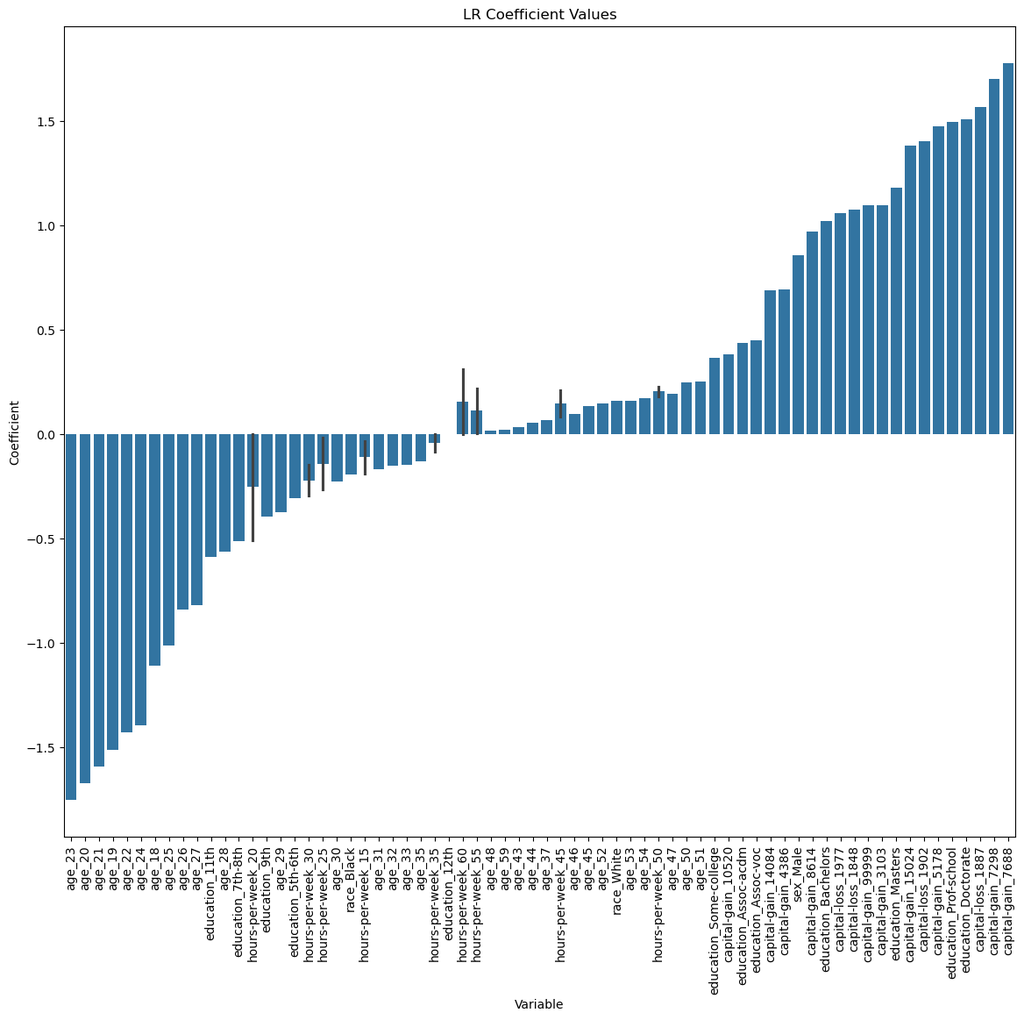

```python
#9. Barplot of the coefficients sorted in ascending order.
plt.figure(figsize=(14, 12))  # Optional: Adjust the figure size as needed
sns.barplot(data=coeff_df, x='Variable', y='Coefficient')
plt.xticks(rotation=90);
plt.title('LR Coefficient Values')
plt.show()
plt.clf()
```

```python
#10. Plot the ROC curve and print the AUC value.
y_pred_prob = log_reg.predict_proba(x_test)
```

```python
# Step 1: Get the probability estimates
y_pred_prob = log_reg.predict_proba(x_test)[:, 1]
```

```python
# Step 2: Compute TPR, FPR, and thresholds
fpr, tpr, thresholds = roc_curve(y_test, y_pred_prob)
```

```python
from sklearn.model_selection import GridSearchCV

# Define hyperparameters for tuning
param_grid = {'C': [0.1, 1, 10], 'solver': ['liblinear', 'lbfgs']}

# Create GridSearchCV object
grid = GridSearchCV(LogisticRegression(), param_grid, cv=5)
grid.fit(X_train, y_train)

# Print best parameters
print("Best Parameters:", grid.best_params_)

# Use the best parameters for the final model
best_model = grid.best_estimator_
```

[output not shown]

```
Best Parameters: {'C': 10, 'solver': 'liblinear'}
```

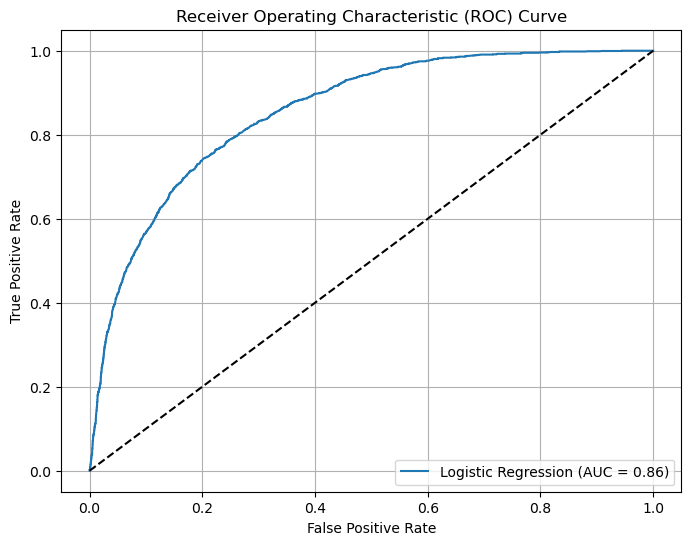

```python
# Step 4: Plot the ROC curve
# Plotting the Receiver Operating Characteristic (ROC) curve and print the Area Under the Curve (AUC) value for the logistic regression model.
# Use the predict_proba method on the logistic regression model to get the probability estimates for the test set. This method returns probabilities for each class, and we  need the probabilities for the positive class (e.g., income > 50K).
# Use the roc_curve function from sklearn.metrics to compute the true positive rate (TPR), false positive rate (FPR), and thresholds for different decision boundaries.
# Use the roc_auc_score function from sklearn.metrics to calculate the AUC value.
# Plot the ROC curve using matplotlib.

# Get probability estimates for the positive class
y_proba = best_model.predict_proba(X_test)[:, 1]

# Calculate FPR, TPR, and thresholds using roc_curve
fpr, tpr, thresholds = roc_curve(y_test, y_proba)

# Calculate AUC value
auc_value = roc_auc_score(y_test, y_proba)

# Plot the ROC curve
plt.figure(figsize=(8, 6))
plt.plot(fpr, tpr, label=f'Logistic Regression (AUC = {auc_value:.2f})')
plt.plot([0, 1], [0, 1], 'k--')  # Dashed diagonal line for random chance
plt.xlabel('False Positive Rate')
plt.ylabel('True Positive Rate')
plt.title('Receiver Operating Characteristic (ROC) Curve')
plt.legend(loc='lower right')
plt.grid()
plt.show()
```

```python
# Step 3: Calculate the AUC value
auc_value = roc_auc_score(y_test, y_pred_prob)
print(f'AUC Value: {auc_value}')
```

```
AUC Value: 0.5042709054132173
```

### Future Work

- Experiment with different classification algorithms such as Random Forest or Support Vector Machine (SVM).
- Address data imbalance using techniques like SMOTE or class weighting.
- Perform feature selection to reduce dimensionality and improve model interpretability.